# R Case Study2

# R Case Study2-employee Attrition link for the git https://github.com/SMU-UNO/CaseStudy2

## Your team has been given a dataset (CaseStudy2Data.zip) to conduct exploratory data analysis (EDA) to determine factors that lead to attrition. You should identify (at least) the top three factors that contribute to turnover. There may or may not be a need to create derived attributes/variables. The business is also interested in learning about any job role specific trends that may exist in the data set (e.g., ââ¬Å“Data Scientists have the highest job satisfactionââ¬). You can also provide any other interesting trends and observations from your analysis. The analysis should be backed up by robust experimentation and (where applicable) appropriate visualization. Experiments and analysis must be conducted in R. If needed, consult with the business owner to get clarifications on the dataset or business goals.

```r
employee <- read.csv("https://raw.githubusercontent.com/SMU-UNO/CaseStudy2/master/RawData/CaseStudy2-data.csv", header=TRUE, sep=",")
head(employee)
```

```
##   ï..Age Attrition    BusinessTravel DailyRate             Department
## 1     41       Yes     Travel_Rarely      1102                  Sales
## 2     49        No Travel_Frequently       279 Research & Development
## 3     37       Yes     Travel_Rarely      1373 Research & Development
## 4     33        No Travel_Frequently      1392 Research & Development
## 5     27        No     Travel_Rarely       591 Research & Development
## 6     32        No Travel_Frequently      1005 Research & Development
##   DistanceFromHome Education EducationField EmployeeCount EmployeeNumber
## 1                1         2  Life Sciences             1              1
## 2                8         1  Life Sciences             1              2
## 3                2         2          Other             1              4
## 4                3         4  Life Sciences             1              5
## 5                2         1        Medical             1              7
## 6                2         2  Life Sciences             1              8
##   EnvironmentSatisfaction Gender HourlyRate JobInvolvement JobLevel
```

[output cut: 48 more lines]

```r
#Drop the the columns with no variability.

#Drop Over18 as there is no variability, all are Y.
#Drop EmployeeCount as there is no variability, all are 1.
#Drop StandardHours as there is no variability, all are 80.

library(caret)
```

```r
library(ggplot2)
library(ggthemes)
library(dplyr)
library(dygraphs)
nearZeroVar(employee)
```

```
## [1]  9 22 27
```

```r
employee$Over18 <- NULL
employee$EmployeeCount <- NULL
employee$StandardHours <- NULL
```

# Exploratory Data Analysis

# Attrition

```r
table(employee$Attrition)
```

```
##
##   No  Yes
## 1233  237
```

```r
prop.table(table(employee$Attrition))
```

```
##
##        No       Yes
## 0.8387755 0.1612245
```

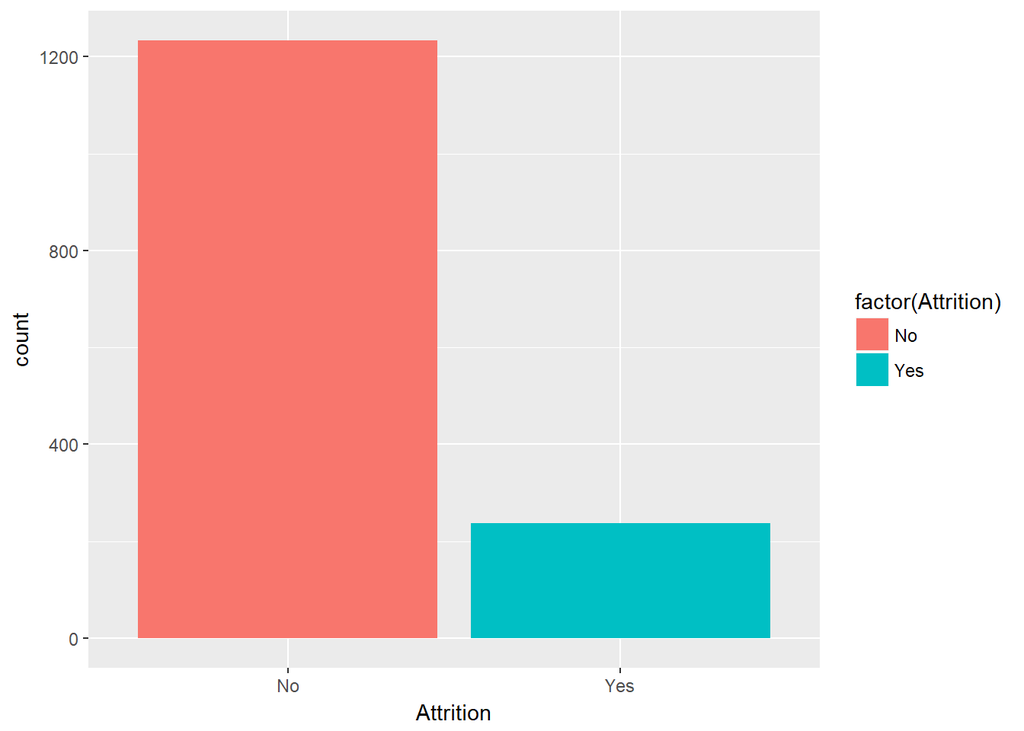

```r
ggplot(employee, aes(Attrition, fill=factor(Attrition))) + geom_bar()
```